# Text Pre-Processing, LDA Model, and Posterior Prediction Model

Stephanie Langeland

# 1 Import files & set up the corpus

```r
##:::::::::::::::::::::::::::::::::::::::::: Import Data:
library(tm)

path <- "/Users/stephanielangeland/Desktop/Columbia/masters_thesis/Langeland_thesis/input_output_files/open_close_data.rds"

raw_corpus <- readRDS(path)

library(dplyr)
```

Extract statements:

```r
stmt_sub <- raw_corpus %>%
  filter(!is.na(stmt_text))
```

Extract minutes:

```r
min_sub <- raw_corpus %>%
  filter(!is.na(min_text))
```

Stack minutes and statements, with their corresponding meta data (response variables), into a data frame:

```r
texts_orig <- data.frame(
  doc_id = c(paste0(stmt_sub$release_date, "_s"),
             paste0(min_sub$release_date, "_m")),
  text = c(stmt_sub$stmt_text,
           min_sub$min_text),
  release_date = c(stmt_sub$release_date,
                   min_sub$release_date),
  stringsAsFactors = F)
```

Merge the statements and minutes text with the meta data (response variables):

```r
texts <- merge(
  x = texts_orig,
  y = raw_corpus[ , c(2, ## release date
                      5:ncol(raw_corpus))], ## response variables
  by = "release_date"
  )

colnames(texts)
```

```
##  [1] "release_date"              "doc_id"
##  [3] "text"                      "BICLB10Y_LAST_PRICE"
##  [5] "CLAComdty_ASK_PRICE"       "CLAComdty_BID_PRICE"
##  [7] "CLAComdty_change"          "CLAComdty_change_cat"
##  [9] "CLAComdty_HIGH_PRICE"      "CLAComdty_LAST_PRICE"
## [11] "CLAComdty_LOW_PRICE"       "CLAComdty_OPEN_PRICE"
## [13] "CLAComdty_VOLUME"          "H15T10Y_change"
## [15] "H15T10Y_change_cat"        "H15T10Y_HIGH_PRICE"
## [17] "H15T10Y_LAST_PRICE"        "H15T10Y_LOW_PRICE"
## [19] "H15T10Y_OPEN_PRICE"        "MOODCBAA_LAST_PRICE"
## [21] "SPX_ASK_PRICE"             "SPX_BID_PRICE"
## [23] "SPX_change"                "SPX_change_cat"
## [25] "SPX_HIGH_PRICE"            "SPX_LAST_PRICE"
## [27] "SPX_LOW_PRICE"             "SPX_OPEN_PRICE"
## [29] "SPX_VOLUME"                "TNX_ADJ_CLOSE_PRICE"
## [31] "TNX_change"                "TNX_change_cat"
## [33] "TNX_CLOSE_PRICE"           "TNX_HIGH_PRICE"
## [35] "TNX_LOW_PRICE"             "TNX_OPEN_PRICE"
## [37] "USSOC_ASK_PRICE"           "USSOC_BID_PRICE"
## [39] "USSOC_change"              "USSOC_change_cat"
## [41] "USSOC_HIGH_PRICE"          "USSOC_LAST_PRICE"
## [43] "USSOC_LOW_PRICE"           "USSOC_OPEN_PRICE"
## [45] "VIX_change"                "VIX_change_cat"
## [47] "VIX_HIGH_PRICE"            "VIX_LAST_PRICE"
## [49] "VIX_LOW_PRICE"             "VIX_OPEN_PRICE"
## [51] "CLAComdty_close_perc_open" "H15T10Y_close_perc_open"
## [53] "SPX_close_perc_open"       "TNX_close_perc_open"
## [55] "USSOC_close_perc_open"     "VIX_close_perc_open"
```

```r
#str(texts)

#View(texts)
```

Combine documents that were released on the same day:

```r
##:::::::::::::::::::: On which dates were multiple docs released on same day:
dup_dates_location <- which(duplicated(texts$release_date) == TRUE)

duplicated_date <- texts[dup_dates_location, "release_date"]
duplicated_date ## only one date when multiple (two) docs were released
```

```
## [1] "1999-06-30"
```

```r
dup_dates2 <- which(texts$release_date == duplicated_date)
dup_dates2 ## rows 44 and 45 are the same date
```

```
## [1] 44 45
```

```r
##:::::::::::::::::::: Combine documents that were released on the same
##:::::::::::::::::::: day - combine rows 44 and 45 into row 44:
texts$text[ dup_dates2[1] ] <- paste(
  texts[ dup_dates2[1], c("text")], ## row 44
  texts[ dup_dates2[2], c("text")] ## row 45
                                      )



##:::::::::::::::::::: Update the doc_id in row 44:
texts$doc_id[ dup_dates2[1] ] <- paste(
  duplicated_date,
  "_ms",
  sep = ""
)



##:::::::::::::::::::: Delete the duplicate row (row 45):
texts <- texts[-dup_dates2[2], ]



###::::::::::::::::::::  Verify that there are no more duplicate dates:
summary(duplicated(texts$release_date))
```

```
##    Mode   FALSE
## logical     352
```

Use the `stringr` package to do this now because the `removePunctuation` function isn’t catching everything later on and remove this special character:

```r
library(stringr)

texts$text <- str_replace_all(
  texts$text,
  "[:punct:]",
  " "
)

texts$text <- str_replace_all(
  texts$text,
  "�",
  ""
)
```

Fix spelling errors:

```r
texts$text <- str_replace_all(
  texts$text,
  "accomodative",
  "accommodative"
)
```

No real difference between “economy” vs. “economic” for a machine:

```r
## use "economic" instead because it is said more times than "economy":
text_sub <- unlist(
  texts$text
)

text_sub <- tolower(text_sub)

sum(
  str_count(text_sub,
            "economy")
)
```

```
## [1] 1662
```

```r
sum(
  str_count(text_sub,
            "economic")
)
```

```
## [1] 6962
```

```r
texts$text <- str_replace_all(
  texts$text,
  "economy",
  "economic"
)
```

No real difference between “accrue” vs. “accrual” for a machine:

```r
texts$text <- str_replace_all(
  texts$text,
  "accrued",
  "accrue"
)

texts$text <- str_replace_all(
  texts$text,
  "accruing",
  "accrue"
)

texts$text <- str_replace_all(
  texts$text,
  "accrual",
  "accrue"
)

texts$text <- str_replace_all(
  texts$text,
  "accruals",
  "accrue"
)
```

Create a corpus data frame:

```r
df_source <- DataframeSource(texts) ## this is the source of the corpus data frame

df_corpus <- VCorpus(df_source) ## create a volatile corpus

#View(df_corpus)

print(df_corpus) ## contains the correct number of documents
```

```
## <<VCorpus>>
## Metadata:  corpus specific: 0, document level (indexed): 54
## Content:  documents: 352
```

```r
#inspect(df_corpus)

head(meta(df_corpus)) ## response variables are saved as meta data
```

```
##   release_date BICLB10Y_LAST_PRICE CLAComdty_ASK_PRICE CLAComdty_BID_PRICE
## 1   1995-02-01               128.2                  NA                  NA
## 2   1995-03-30               149.9                  NA                  NA
## 3   1995-05-25               162.3                  NA                  NA
## 4   1995-07-06               183.7                  NA                  NA
## 5   1995-07-10               179.9                  NA                  NA
## 6   1995-08-24               172.7                  NA                  NA
##   CLAComdty_change CLAComdty_change_cat CLAComdty_HIGH_PRICE
## 1               NA                   NA                   NA
## 2               NA                   NA                   NA
## 3               NA                   NA                   NA
## 4               NA                   NA                   NA
## 5               NA                   NA                   NA
## 6               NA                   NA                   NA
##   CLAComdty_LAST_PRICE CLAComdty_LOW_PRICE CLAComdty_OPEN_PRICE
```

[output cut: 90 more lines]

# 2 Pre-process the corpus `df_corpus`

Convert all words to lowercase:

```r
df_corpus <- tm_map(
  df_corpus,
  content_transformer(tolower)
)
```

Remove white space:

```r
df_corpus <- tm_map(
  df_corpus,
  stripWhitespace
)
```

Remove numbers:

```r
df_corpus <- tm_map(
  df_corpus,
  removeNumbers
)
```

Remove stop words:

```r
df_corpus <- tm_map(
  df_corpus,
  removeWords,
  stopwords("english")
)
```

Remove Fed employees’ names and titles, FRB cities, months, days of the week, country names and abbreviations, punctuation; stem words to the root:

```r
delete_words <- read.csv(
  "/Users/stephanielangeland/Desktop/Columbia/masters_thesis/Langeland_thesis/input_output_files/delete_words.csv"
)

str(delete_words)
```

```
## 'data.frame':    736 obs. of  1 variable:
##  $ delete_words: Factor w/ 735 levels "about","AD","Adolph",..: 2 3 4 5 6 7 8 9 10 11 ...
```

```r
delete_words$delete_words <- as.character(delete_words$delete_words)

delete_words$delete_words <- tolower(delete_words$delete_words) ## convert to lower case

delete_words <- unlist(delete_words$delete_words)

df_corpus <- tm_map(
  df_corpus,
  removeWords,
  delete_words
)



##:::::::::::::::::::: Delete names of U.S. States:
df_corpus <- tm_map(
  df_corpus,
  removeWords,
  tolower(state.abb) ## state abbreviations
)

df_corpus <- tm_map(
  df_corpus,
  removeWords,
  tolower(state.name) ## full names of states
)

df_corpus <- tm_map(
  df_corpus,
  removeWords,
  tolower(state.region) ## U.S. regions
)



##:::::::::::::::::::: Remove punctuation:
df_corpus <- tm_map(
  df_corpus,
  removePunctuation
)
```

```r
##:::::::::::::::::::: Delete names of U.S. cities:
library(maps)

cities <- unlist(
  tolower(
    us.cities$name
  )
)



##:::::::::::::::::::: Stem words:
df_corpus <- tm_map(
  df_corpus,
  stemDocument
)
```

# 3 Create a document-term matrix (`dtm`)

```r
dtm <- DocumentTermMatrix(
  df_corpus
  )

#dim(dtm)
str(dtm)
```

```
## List of 6
##  $ i       : int [1:176522] 1 1 1 1 1 1 1 1 1 1 ...
##  $ j       : int [1:176522] 48 51 72 105 212 327 412 430 598 628 ...
##  $ v       : num [1:176522] 2 1 1 1 2 2 1 1 1 1 ...
##  $ nrow    : int 352
##  $ ncol    : int 4613
##  $ dimnames:List of 2
##   ..$ Docs : chr [1:352] "1995-02-01_s" "1995-03-30_m" "1995-05-25_m" "1995-07-06_s" ...
##   ..$ Terms: chr [1:4613] "aaa" "aaronson" "abandon" "abat" ...
##  - attr(*, "class")= chr [1:2] "DocumentTermMatrix" "simple_triplet_matrix"
##  - attr(*, "weighting")= chr [1:2] "term frequency" "tf"
```

```r
dtm
```

```
## <<DocumentTermMatrix (documents: 352, terms: 4613)>>
## Non-/sparse entries: 176522/1447254
## Sparsity           : 89%
## Maximal term length: 24
## Weighting          : term frequency (tf)
```

```r
dtm_mat <- as.matrix(dtm)
```

```r
set.seed(1234)

dtm1 <- removeSparseTerms(dtm,
                          sparse = 0.3)

dtm1
```

```
## <<DocumentTermMatrix (documents: 352, terms: 61)>>
## Non-/sparse entries: 17499/3973
## Sparsity           : 19%
## Maximal term length: 9
## Weighting          : term frequency (tf)
```

```r
dtm1_mat <- as.matrix(dtm1)

head(dtm1_mat)
```

```
##               Terms
## Docs           action activ anticip appear balanc busi condit consist
##   1995-02-01_s      2     1       0      0      0    0      0       0
##   1995-03-30_m     15    15       8      7     14   17     15       9
##   1995-05-25_m      7    18       8      8     20   19     11       9
##   1995-07-06_s      1     0       0      0      0    0      1       0
##   1995-07-10_m      2    12       6      9      9   18     10       5
##   1995-08-24_m      8    10       8      7     15   19      8      11
##               Terms
## Docs           continu current decid develop econom employ energi expand
##   1995-02-01_s       1       0     0       0      2      0      0      0
##   1995-03-30_m      26      14     3      19     52      4      6      3
##   1995-05-25_m      16       6     1      13     42      3      1      0
##   1995-07-06_s       0       0     1       0      0      0      0      0
##   1995-07-10_m      26      12     2      13     39      3      4      3
##   1995-08-24_m      20      16     2      20     59      6      4      5
##               Terms
## Docs           expect financi foster fund growth hous household improv
##   1995-02-01_s      0       0      1    0      2    0         0      0
##   1995-03-30_m     11      25      4    5     60    9         0      2
##   1995-05-25_m     16      14      3    6     34   10         1      3
##   1995-07-06_s      0       0      0    1      0    0         0      0
##   1995-07-10_m     16      15      1    3     34    6         2      6
##   1995-08-24_m     19      20      4    7     75    8         1      6
##               Terms
## Docs           incom increas indic inflat inform invest labor level like
##   1995-02-01_s     0       2     0      1      0      0     0     0    0
##   1995-03-30_m     7      39    11     25     12     10     4    23   15
##   1995-05-25_m     5      25     7     14      7     11     4    16    6
##   1995-07-06_s     0       0     0      0      0      0     0     0    0
##   1995-07-10_m     5      21     9     11      7      6     5    12   14
##   1995-08-24_m     7      28    14     20      5      5     7    15   12
##               Terms
## Docs           longer low maintain market measur moder month open outlook
##   1995-02-01_s      0   0        0      2      0     1     0    1       0
##   1995-03-30_m      3   5        4     40      7    20    20   16       5
##   1995-05-25_m      0   6       13     70      3    16    30   48       6
##   1995-07-06_s      0   0        0      1      0     0     0    1       0
##   1995-07-10_m      4   6        6     34      4    14    14   11       9
##   1995-08-24_m      3   2        3     30      9    21    25   10       9
##               Terms
## Docs           pace pressur price quarter rang rate recent remain risk run
##   1995-02-01_s    1       0     0       0    0    4      0      0    0   0
##   1995-03-30_m    7      14    36      33   32   33     16     10   10   9
##   1995-05-25_m    9       8    25      12    5   38     27     14    4   4
##   1995-07-06_s    0       2     0       0    0    1      0      0    0   0
##   1995-07-10_m   12      12    28      23   12   32     10     15    4   4
##   1995-08-24_m    8      18    35      31   61   45     27     26   13   7
##               Terms
## Docs           secur spend stabil support sustain target term time year
##   1995-02-01_s     0     0      0       0       1      0    0    0    0
##   1995-03-30_m     1    11     14       7      10      6    9   14   33
##   1995-05-25_m    21    15      9       4      10      0   14   18   12
##   1995-07-06_s     0     0      0       0       0      0    0    0    0
##   1995-07-10_m     3     8      6       4      11      0   13    4   18
##   1995-08-24_m     1    12     14       8      10      2   10   13   39
```

```r
#View(sort(colnames(dtm1_mat)))
```

# 4 Model inputs

```r
##:::::::::::::::::::: Number of documents:
M <- nrow(dtm1_mat)



##:::::::::::::::::::: Integer array of size M - each of its elements is the
##:::::::::::::::::::: number of words in that document:
N <- rowSums(dtm1_mat)



##:::::::::::::::::::: Number of words in the vocabulary which is the total
##:::::::::::::::::::: number of words:
V <- ncol(dtm1_mat)
```

Some experimentation analysis led me to choose the following priors/model inputs:

```r
##:::::::::::::::::::: Number of topics:
K <- 3

##:::::::::::::::::::: Beta:
beta_3 <- rep(
  200 / V,
  V ## vector size V
  )



##:::::::::::::::::::: Alpha:
##::::::::: I experimented with alpha: lower values yield more
##::::::::: polarized outcomes and higher yield more concentrated outcomes
##::::::::: so am aiming for higher values):
alpha_3 <- rep(
  100 / K,
  K ## size K
  )
```

# 5 Prior predicitve distribution

```r
library(rstan)
library(rstanarm)
```

```r
setwd("/Users/stephanielangeland/Desktop/Columbia/masters_thesis/Langeland_thesis/code")

expose_stan_functions("LDApriors_rng.stan")

prior_LDA_dtm_1 <- LDA_rng(
  V = V,
  beta = beta_3,
  K = K,
  alpha = alpha_3,
  M = M,
  N = N
)
```

```r
##:::::::::::::::::::: How closely does my prior document term matrix
##:::::::::::::::::::: (`prior_LDA_dtm_1`) resemble my actual document term
##:::::::::::::::::::: matrix (`dtm1_mat`):

#View(prior_LDA_dtm_1)
#View(dtm1_mat)

#summary(prior_LDA_dtm_1 - dtm1_mat) == 0
hist(prior_LDA_dtm_1 - dtm1_mat)

summary(
  rowSums(prior_LDA_dtm_1) -
    rowSums(dtm1_mat)
)

#sum((prior_LDA_dtm_1 - dtm1_mat) == 0)
#sum((prior_LDA_dtm_1 - dtm1_mat) != 0)

round(
  (
  sum( ( prior_LDA_dtm_1 - dtm1_mat) == 0 ) /
    ( ncol(dtm1_mat) * nrow(dtm1_mat) )
       * 100
       ),
      digits = 2
  ) ## percentage of `prior_LDA_dtm_1` values that match `dtm1_mat`
```

# 6 LDA model and posterior prediction model of past data

```r
library(tidytext)

library(dplyr)
```

```r
##:::::::::::::::::::: Convert `df_corpus` into a single data frame column:
text_df <- as.data.frame(
  do.call(
    rbind,
    lapply(
      df_corpus,
      FUN = as.character
      )
  ),
  stringsAsFactors = FALSE
)



##:::::::::::::::::::: Rename the column:
colnames(text_df) <- "text"



##:::::::::::::::::::: `doc_id`:
text_df$doc <- 1:nrow(text_df)



##:::::::::::::::::::: Get word stems:
text_df <- text_df %>%
  unnest_tokens(
    wordstem,
    text
  )



##:::::::::::::::::::: Create a flattened dtm:
text_df <- text_df[text_df$wordstem %in%
                     colnames(dtm1_mat), ]



##:::::::::::::::::::: Create a data frame of the response variables
##:::::::::::::::::::: (`close_perc_open` variables only):
response_vars <- meta(df_corpus)

response_vars_all <- response_vars[ , 49:54]

summary(is.na(response_vars_all))
```

```
##  CLAComdty_close_perc_open H15T10Y_close_perc_open SPX_close_perc_open
##  Mode :logical             Mode :logical           Mode :logical
##  FALSE:36                  FALSE:352               FALSE:352
##  TRUE :316
##  TNX_close_perc_open USSOC_close_perc_open VIX_close_perc_open
##  Mode :logical       Mode :logical         Mode :logical
##  FALSE:352           FALSE:267             FALSE:352
##                      TRUE :85
```

```r
##^ `CLAComdty_close_perc_open` & `USSOC_close_perc_open` suffer from missingness
## which cannot be accepted by the below posterior prediction stan model so must
## eliminate those variables.



##:::::::::::::::::::: Final response variables data frame (without
##:::::::::::::::::::: `CLAComdty_close_perc_open` & `USSOC_close_perc_open`):
response_vars_sub <- response_vars_all[ , c(2:4, 6)]



##:::::::::::::::::::: Input data for the below posterior prediction stan model:
dat <- with(text_df,
            list(

              K = K,

              V = ncol(dtm1_mat),

              M = nrow(dtm1_mat),

              N = nrow(text_df),

              w = as.integer(factor(
                wordstem,
                levels = colnames(dtm1_mat)
                )
                             ),

              doc = doc,

              alpha_mean = 1,

              beta = rep( 1 / K,
                          ncol(dtm1_mat)
                          ),

              P = ncol(response_vars_sub), ## number of stocks

              Y = response_vars_sub,  ## price changes

              alpha_stock = 0, ## intercept: probability that this stock prices swings this much per day

              beta_stock_raw =  0,

              tau_mean = 1, ## standard deviation in coefficient across words

              sigma_mean = 6, ## std devs on non-fomc and fomc dates for spx closing prices

              DTM = ( dtm1_mat / rowSums(dtm1_mat) )

              )
            )
```

```r
##:::::::::::::::::::: Posterior prediction stan model:
start_time <- Sys.time() ## record how long the model takes to run


post <- stan("LDA.stan",
             data = dat,
             cores = parallel::detectCores()
             )


end_time <- Sys.time() ## record how long the model takes to run

end_time - start_time ## how long the stan model took to run (about 8.5 hours on 4 cores)


setwd("/Users/stephanielangeland/Desktop/Columbia/masters_thesis/Langeland_thesis/input_output_files")

saveRDS(post,
        file = "post_20180424.rds") ## save the output of the stan mdoel
```

```r
test <- readRDS(
  "/Users/stephanielangeland/Desktop/Columbia/masters_thesis/Langeland_thesis/input_output_files/post_20180424.rds"
  )

post <- test

#post
```

## 6.1 Explaination of the output (`post`)

*Refer to the paper for more details.*

```r
Y_tilde <- extract(post,
                   pars = "Y_tilde",
                   permuted = FALSE
                   )

#Y_tilde

length(Y_tilde)
```

```
## [1] 5632000
```

```r
dim(Y_tilde)
```

```
## [1] 1000    4 1408
```

## 6.2 Explaination of the output (`Y_tilde`)

*Refer to the paper for more details.*

`Y_tilde` is the number of iterations (1000) by the number of chains (4) by the number of Fed days (352) times the number of response variables (4) (which equals 1408). Each `Y_tilde` matrix was collapsed into a vector. There is 1 matrix for each iteration and chain within `Y_tilde`.

# 7 Posterior predictive checks

*Refer to the paper for more details.*

## 7.1 Check how well the model predicts the response variables

Create a matrix that contains the differences between the predictions and actual response variables, then calculate the average of all of those posterior draws:

```r
options(scipen = 999)

model_residuals <- apply(
  Y_tilde,
  1:2,
  FUN = function(y) response_vars_sub - matrix(y,
                                               nrow = 352,
                                               ncol = 4)
)


model_residuals_avg <- Reduce("+", model_residuals) / length(model_residuals)

str(model_residuals_avg)
```

```
## 'data.frame':    352 obs. of  4 variables:
##  $ H15T10Y_close_perc_open: num  -0.0385 -0.0914 -0.0478 -0.031 -0.0267 ...
##  $ SPX_close_perc_open    : num  -0.0111 -0.0046 -0.00207 0.00395 -0.00159 ...
##  $ TNX_close_perc_open    : num  0.002644 0.007951 0.000372 -0.028383 -0.003151 ...
##  $ VIX_close_perc_open    : num  -0.00944 -0.00453 0.00862 0.06281 -0.08484 ...
```

```r
head(model_residuals_avg)
```

```
##   H15T10Y_close_perc_open SPX_close_perc_open TNX_close_perc_open
## 1             -0.03846488        -0.011095936        0.0026439958
## 2             -0.09142136        -0.004595859        0.0079513124
## 3             -0.04783348        -0.002066869        0.0003724572
## 4             -0.03103787         0.003953571       -0.0283830650
## 5             -0.02671477        -0.001589004       -0.0031514207
## 6              0.04743968        -0.003010088       -0.0161601666
##   VIX_close_perc_open
## 1        -0.009438363
## 2        -0.004527864
## 3         0.008615711
## 4         0.062806372
## 5        -0.084840707
## 6         0.025230688
```

```r
model_residuals_avg_abs <- abs(model_residuals_avg) ## take the absolute value
```

### 7.1.1 Range rediction accuracy

*Check to see how close the predictions are to the actual response variables* *(within a range - one standard deviation of the corresponding response variable).*

**`H15T10Y_close_perc_open` - 10-year constant maturity rate:**

```r
##:::::::::::::::::::: Are the predictions within 1 standard deviation of
##:::::::::::::::::::: `H15T10Y_close_perc_open`?:
model_residuals_avg_abs_rng_h15 <- ifelse(
  model_residuals_avg_abs$H15T10Y_close_perc_open <= sd(response_vars_sub$H15T10Y_close_perc_open),
  "within_range",
  "out_of_range"
)

model_residuals_avg_abs_rng_h15 <- as.data.frame(model_residuals_avg_abs_rng_h15)

summary(model_residuals_avg_abs_rng_h15)
```

```
##  model_residuals_avg_abs_rng_h15
##  out_of_range: 91
##  within_range:261
```

```r
##::::::::: Percentage of each variable that was predicted "within range":
rng_h15_pred <- sum(model_residuals_avg_abs_rng_h15 == "within_range") /
  nrow(model_residuals_avg_abs_rng_h15) * 100

rng_h15_pred
```

```
## [1] 74.14773
```

74.15% of the time, the model correctly predicted the change in the 10-year constant maturity rate within 1 standard deviation of observed data for the 10-year constant maturity rate.

**`SPX_close_perc_open` - S&P 500 Index:**

```r
##:::::::::::::::::::: Are the predictions within 1 standard deviation of
##:::::::::::::::::::: `SPX_close_perc_open`?:
model_residuals_avg_abs_rng_spx <- ifelse(
  model_residuals_avg_abs$SPX_close_perc_open <= sd(response_vars_sub$SPX_close_perc_open),
  "within_range",
  "out_of_range"
)

model_residuals_avg_abs_rng_spx <- as.data.frame(model_residuals_avg_abs_rng_spx)

summary(model_residuals_avg_abs_rng_spx)
```

```
##  model_residuals_avg_abs_rng_spx
##  out_of_range: 68
##  within_range:284
```

```r
##::::::::: Percentage of each variable that was predicted "within range":
rng_spx_pred <- sum(model_residuals_avg_abs_rng_spx == "within_range") /
  nrow(model_residuals_avg_abs_rng_spx) * 100

rng_spx_pred
```

```
## [1] 80.68182
```

80.68% of the time, the model correctly predicted the change in the S&P 500 Index within 1 standard deviation of observed data for the S&P 500 Index.

**`TNX_close_perc_open` - CBOE interest rate on the 10 year Treasury Note:**

```r
##:::::::::::::::::::: Are the predictions within 1 standard deviation of
##:::::::::::::::::::: `TNX_close_perc_open`?:
model_residuals_avg_abs_rng_tnx <- ifelse(
  model_residuals_avg_abs$TNX_close_perc_open <= sd(response_vars_sub$TNX_close_perc_open),
  "within_range",
  "out_of_range"
)

model_residuals_avg_abs_rng_tnx <- as.data.frame(model_residuals_avg_abs_rng_tnx)

summary(model_residuals_avg_abs_rng_tnx)
```

```
##  model_residuals_avg_abs_rng_tnx
##  out_of_range: 82
##  within_range:270
```

```r
##::::::::: Percentage of each variable that was predicted "within range":
rng_tnx_pred <- sum(model_residuals_avg_abs_rng_tnx == "within_range") /
  nrow(model_residuals_avg_abs_rng_tnx) * 100

rng_tnx_pred
```

```
## [1] 76.70455
```

76.7% of the time, the model correctly predicted the change in the CBOE interest rate on the 10 year Treasury Note within 1 standard deviation of observed data for this rate.

**`VIX_close_perc_open` - VIX Index:**

```r
##:::::::::::::::::::: Are the predictions within 1 standard deviation of
##:::::::::::::::::::: `VIX_close_perc_open`?:
model_residuals_avg_abs_rng_vix <- ifelse(
  model_residuals_avg_abs$VIX_close_perc_open <= sd(response_vars_sub$VIX_close_perc_open),
  "within_range",
  "out_of_range"
)

model_residuals_avg_abs_rng_vix <- as.data.frame(model_residuals_avg_abs_rng_vix)

summary(model_residuals_avg_abs_rng_vix)
```

```
##  model_residuals_avg_abs_rng_vix
##  out_of_range: 80
##  within_range:272
```

```r
##::::::::: Percentage of each variable that was predicted "within range":
rng_vix_pred <- sum(model_residuals_avg_abs_rng_vix == "within_range") /
  nrow(model_residuals_avg_abs_rng_vix) * 100

rng_vix_pred
```

```
## [1] 77.27273
```

77.27% of the time, the model correctly predicted the change in the VIX within 1 standard deviation of observed data for the VIX.

Overall, the model correctly predicted the changes in the closing value as a percentage of the opening value, within 1 standard deviation of each respective response variable, well.

### 7.1.2 Directional prediction accuracy

It is also a problem if the predictions are going in the wrong direction e.g., if any of the `response_vars_sub` values > 1 then the close > open price so the value went up after the Fed release. On the other hand, if the `response_vars_sub` < 1 then the close < open price so the value went down after the Fed release. If the prediction > 1 and the corresponding `response_vars_sub` value < 1 then the model predicted the security moving in the wrong direction which is an issue. In this section , I create a measure of whether `model_residuals_avg` accurately predicts the direction of the response variables (`response_vars_sub`).

Put the predictions in matrix format for each chain and iteration:

```r
##:::::::::::::::::::: Convert the post output to a matrix:
post_mat <- as.matrix(post)

str(post_mat)
```

```
##  num [1:4000, 1:3128] 0.463 0.46 0.46 0.446 0.404 ...
##  - attr(*, "dimnames")=List of 2
##   ..$ iterations: NULL
##   ..$ parameters: chr [1:3128] "alpha[1]" "alpha[2]" "alpha[3]" "theta[1,1]" ...
```

```r
##:::::::::::::::::::: Extract the `Y_tilde` predictions from `post_mat`:
post_mat_Y_tilde <- post_mat[ ,
                              grep("Y_tilde",
                                   colnames(post_mat),
                                   fixed = TRUE)
                              ]

str(post_mat_Y_tilde)
```

```
##  num [1:4000, 1:1408] 1.017 0.959 0.959 1 1.06 ...
##  - attr(*, "dimnames")=List of 2
##   ..$ iterations: NULL
##   ..$ parameters: chr [1:1408] "Y_tilde[1,1]" "Y_tilde[2,1]" "Y_tilde[3,1]" "Y_tilde[4,1]" ...
```

```r
dim(post_mat_Y_tilde)
```

```
## [1] 4000 1408
```

*Note:* The column names in `post_mat_Y_tilde` correspond to the variables in `response_vars_sub` so:

- Any column name with a “,1]” corresponds to “H15T10Y_close_perc_open” (`colnames(response_vars_sub)[1]`).
- Any column name with a “,2]” corresponds to “SPX_close_perc_open” (`colnames(response_vars_sub)[2]`).
- Any column name with a “,3]” corresponds to “TNX_close_perc_open” (`colnames(response_vars_sub)[3]`).
- Any column name with a “,4]” corresponds to “VIX_close_perc_open” (`colnames(response_vars_sub)[4]`).

**Overall:**

```r
overall_direction <- table(
  observed = sign(as.matrix(response_vars_sub) - 1),
  predicted = sign(colMeans(post_mat_Y_tilde) - 1)
  )

rownames(overall_direction)[1] <- "closing < opening"
colnames(overall_direction)[1] <- "closing < opening"

rownames(overall_direction)[2] <- "closing = opening (no change)"

rownames(overall_direction)[3] <- "closing > opening"
colnames(overall_direction)[2] <- "closing > opening"

overall_direction
```

```
##                                predicted
## observed                        closing < opening closing > opening
##   closing < opening                            10               563
##   closing = opening (no change)                 0               138
##   closing > opening                             6               691
```

Overall, for all variables:

1. The model best predicts `closing > opening`
2. It does a bad job of predicting `closing < opening`
3. It NEVER predicts `closing = opening`

**`H15T10Y_close_perc_open` - 10-year constant maturity rate:**

```r
H15T10Y_direction <- table(
  observed = sign(as.matrix(response_vars_sub$H15T10Y_close_perc_open) - 1),
  predicted = sign(colMeans(post_mat_Y_tilde[ ,
                           grep(",1]", ## because colnames(response_vars_sub)[1]
                                colnames(post_mat_Y_tilde),
                                fixed = TRUE)
                           ]) - 1)
  )

rownames(H15T10Y_direction)[1] <- "closing < opening"
colnames(H15T10Y_direction)[1] <- "closing < opening"

rownames(H15T10Y_direction)[2] <- "closing = opening (no change)"

rownames(H15T10Y_direction)[3] <- "closing > opening"
colnames(H15T10Y_direction)[2] <- "closing > opening"


H15T10Y_direction
```

```
##                                predicted
## observed                        closing < opening closing > opening
##   closing < opening                             3               127
##   closing = opening (no change)                 0               124
##   closing > opening                             1                97
```

For the 10-year constant maturity rate: bad predictions overall.

**`SPX_close_perc_open` - S&P 500 Index:**

```r
SPX_direction <- table(
  observed = sign(as.matrix(response_vars_sub$SPX_close_perc_open) - 1),
  predicted = sign(colMeans(post_mat_Y_tilde[ ,
                           grep(",2]", ## because colnames(response_vars_sub)[2]
                                colnames(post_mat_Y_tilde),
                                fixed = TRUE)
                           ]) - 1)
  )

rownames(SPX_direction)[1] <- "closing < opening"
colnames(SPX_direction)[1] <- "closing < opening"

rownames(SPX_direction)[2] <- "closing > opening"
colnames(SPX_direction)[2] <- "closing > opening"

SPX_direction
```

```
##                    predicted
## observed            closing < opening closing > opening
##   closing < opening                 2               157
##   closing > opening                 2               191
```

For the S&P 500 Index:

1. The model best predicts `closing > opening`
2. It does a horrible job of predicting `closing < opening`

**`TNX_close_perc_open` - CBOE interest rate on the 10 year Treasury Note:**

```r
TNX_direction <- table(
  observed = sign(as.matrix(response_vars_sub$TNX_close_perc_open) - 1),
  predicted = sign(colMeans(post_mat_Y_tilde[ ,
                           grep(",3]", ## because colnames(response_vars_sub)[3]
                                colnames(post_mat_Y_tilde),
                                fixed = TRUE)
                           ]) - 1)
  )

rownames(TNX_direction)[1] <- "closing < opening"
colnames(TNX_direction)[1] <- "closing < opening"

rownames(TNX_direction)[2] <- "closing = opening (no change)"

rownames(TNX_direction)[3] <- "closing > opening"
colnames(TNX_direction)[2] <- "closing > opening"

TNX_direction
```

```
##                                predicted
## observed                        closing < opening closing > opening
##   closing < opening                             1               162
##   closing = opening (no change)                 0                12
##   closing > opening                             3               174
```

For the CBOE interest rate on the 10 year Treasury Note:

1. The model does an okay job of predicting `closing > opening`
2. It does a horrible job of predicting `closing < opening`
3. It NEVER predicts `closing = opening`

**`VIX_close_perc_open` - VIX Index:**

```r
VIX_direction <- table(
  observed = sign(as.matrix(response_vars_sub$VIX_close_perc_open) - 1),
  predicted = sign(colMeans(post_mat_Y_tilde[ ,
                           grep(",4]", ## because colnames(response_vars_sub)[4]
                                colnames(post_mat_Y_tilde),
                                fixed = TRUE)
                           ]) - 1)
  )

rownames(VIX_direction)[1] <- "closing < opening"
colnames(VIX_direction)[1] <- "closing < opening"

rownames(VIX_direction)[2] <- "closing = opening (no change)"

rownames(VIX_direction)[3] <- "closing > opening"
colnames(VIX_direction)[2] <- "closing > opening"

VIX_direction
```

```
##                                predicted
## observed                        closing < opening closing > opening
##   closing < opening                             4               117
##   closing = opening (no change)                 0                 2
##   closing > opening                             0               229
```

For the VIX:

1. The model does a good job of predicting `closing > opening`
2. It does a horrible job of predicting `closing < opening`
3. It NEVER predicts `closing = opening`

## 7.2 Model fit

```r
library(ggplot2)
library(bayesplot)
```

### 7.2.1 Density overlay plots

Compare the empirical distribution of the data *Y* to the distributions of simulated/replicated data *Yrep* from the posterior predictive distribution. How well do predictions from the posterior distribution match the true outcome variable that was used to fit the data?

**`H15T10Y_close_perc_open` - 10-year constant maturity rate:**

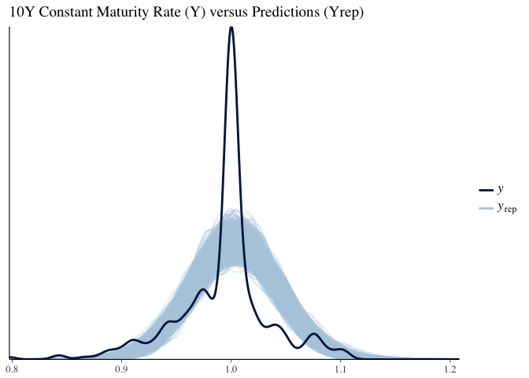

```r
pp_check(
  object = response_vars_sub$H15T10Y_close_perc_open,
  yrep = post_mat_Y_tilde[ ,
                           grep(",1]", ## because colnames(response_vars_sub)[1]
                                colnames(post_mat_Y_tilde),
                                fixed = TRUE)
                           ],
  fun = ppc_dens_overlay
  ) +
  ggtitle("10Y Constant Maturity Rate (Y) versus Predictions (Yrep)")
```

It appears that observed data are more concentrated than the predictions. Thus, the model produced more extreme predictions than what actually occurred in the data.

**`SPX_close_perc_open` - S&P 500 Index:**

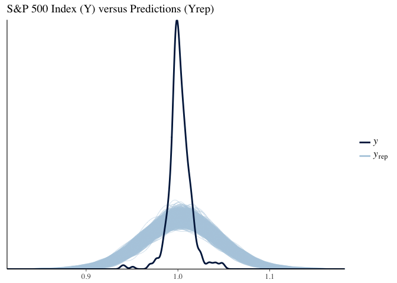

```r
pp_check(
  object = response_vars_sub$SPX_close_perc_open,
  yrep = post_mat_Y_tilde[ ,
                           grep(",2]", ## because colnames(response_vars_sub)[2]
                                colnames(post_mat_Y_tilde),
                                fixed = TRUE)
                           ],
  fun = ppc_dens_overlay
  ) +
  ggtitle("S&P 500 Index (Y) versus Predictions (Yrep)")
```

It appears that observed data are more concentrated than the predictions. Thus, the model produced more extreme predictions than what actually occurred in the data.

**`TNX_close_perc_open` - CBOE interest rate on the 10 year Treasury Note:**

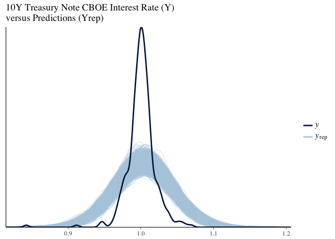

```r
pp_check(
  object = response_vars_sub$TNX_close_perc_open,
  yrep = post_mat_Y_tilde[ ,
                           grep(",3]", ## because colnames(response_vars_sub)[3]
                                colnames(post_mat_Y_tilde),
                                fixed = TRUE)
                           ],
  fun = ppc_dens_overlay
  ) +
  ggtitle("10Y Treasury Note CBOE Interest Rate (Y)\nversus Predictions (Yrep)")
```

It appears that observed data are more concentrated than the predictions. Thus, the model produced more extreme predictions than what actually occurred in the data.

**`VIX_close_perc_open` - VIX Index:**

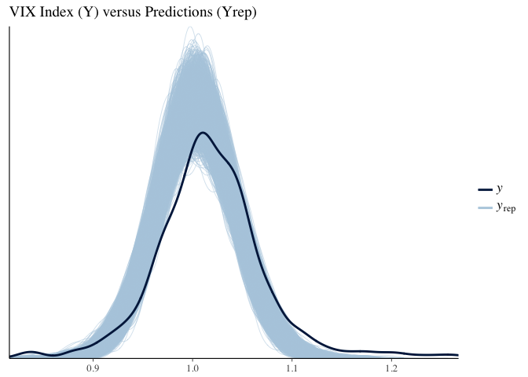

```r
pp_check(
  object = response_vars_sub$VIX_close_perc_open,
  yrep = post_mat_Y_tilde[ ,
                           grep(",4]", ## because colnames(response_vars_sub)[4]
                                colnames(post_mat_Y_tilde),
                                fixed = TRUE)
                           ],
  fun = ppc_dens_overlay
  ) +
  ggtitle("VIX Index (Y) versus Predictions (Yrep)")
```

It appears that predictions are more concentrated than the observed data. Thus, the model produced less extreme predictions than what actually occurred in the data.

### 7.2.2 Marginal distribution plots

Compare the proportion of the observed data that fall within 50% predictive intervals.

**`H15T10Y_close_perc_open` - 10-year constant maturity rate:**

```r
##:::::::::::::::::::: Numerical Assessment of Calibration:
lower_h15 <- apply(
  post_mat_Y_tilde[ ,
                                       grep(",1]", ## because colnames(response_vars_sub)[1]
                                            colnames(post_mat_Y_tilde),
                                            fixed = TRUE)
                                       ],
  MARGIN = 2,
  quantile,
  probs = 0.25
)


upper_h15 <- apply(
  post_mat_Y_tilde[ ,
                                       grep(",1]", ## because colnames(response_vars_sub)[1]
                                            colnames(post_mat_Y_tilde),
                                            fixed = TRUE)
                                       ],
  MARGIN = 2,
  quantile,
  probs = 0.75
)


h15_fit <- mean(response_vars_sub$H15T10Y_close_perc_open > lower_h15 &
       response_vars_sub$H15T10Y_close_perc_open < upper_h15)

h15_fit
```

```
## [1] 0.5965909
```

```
## [1] 59.66
```

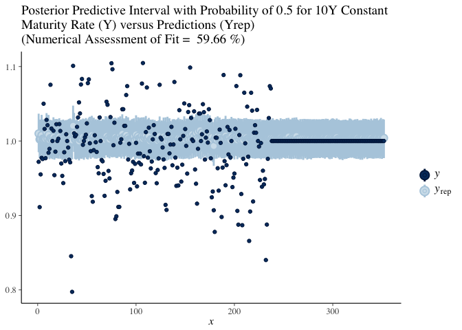

```r
##:::::::::::::::::::: Graphical Assessment of Calibration:
ppc_intervals(y = response_vars_sub$H15T10Y_close_perc_open,
              yrep = post_mat_Y_tilde[ ,
                                       grep(",1]", ## because colnames(response_vars_sub)[1]
                                            colnames(post_mat_Y_tilde),
                                            fixed = TRUE)
                                       ],
              prob = 0.5
) +
  ggtitle(
    paste(
      "Posterior Predictive Interval with Probability of 0.5 for 10Y Constant\nMaturity Rate (Y) versus Predictions (Yrep)",
      "\n(Numerical Assessment of Fit = ",
      print(
        round( h15_fit * 100, digits = 2)
      ),
      "%)"
    )
  )
```

Since the `h15_fit` > 50%, the model is over fitting because 59.66% of the data are fitting in the 50% interval.

**`SPX_close_perc_open` - S&P 500 Index:**

```r
##:::::::::::::::::::: Numerical Assessment of Calibration:
lower_spx <- apply(
  post_mat_Y_tilde[ ,
                                       grep(",2]", ## because colnames(response_vars_sub)[2]
                                            colnames(post_mat_Y_tilde),
                                            fixed = TRUE)
                                       ],
  MARGIN = 2,
  quantile,
  probs = 0.25
)


upper_spx <- apply(
  post_mat_Y_tilde[ ,
                                       grep(",2]", ## because colnames(response_vars_sub)[2]
                                            colnames(post_mat_Y_tilde),
                                            fixed = TRUE)
                                       ],
  MARGIN = 2,
  quantile,
  probs = 0.75
)


spx_fit <- mean(response_vars_sub$SPX_close_perc_open > lower_spx &
       response_vars_sub$SPX_close_perc_open < upper_spx)

spx_fit
```

```
## [1] 0.9545455
```

```
## [1] 95.45
```

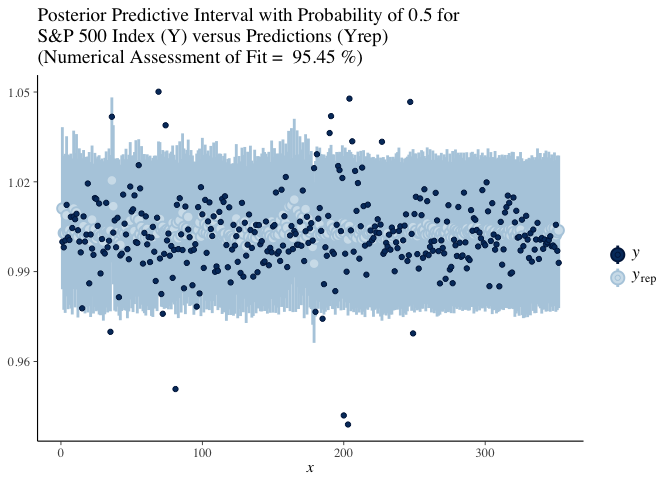

```r
##:::::::::::::::::::: Graphical Assessment of Calibration:
ppc_intervals(y = response_vars_sub$SPX_close_perc_open,
              yrep = post_mat_Y_tilde[ ,
                                       grep(",2]", ## because colnames(response_vars_sub)[2]
                                            colnames(post_mat_Y_tilde),
                                            fixed = TRUE)
                                       ],
              prob = 0.5
) +
  ggtitle(
    paste(
      "Posterior Predictive Interval with Probability of 0.5 for\nS&P 500 Index (Y) versus Predictions (Yrep)",
      "\n(Numerical Assessment of Fit = ",
      print(
        round( spx_fit * 100, digits = 2)
      ),
      "%)"
    )
  )
```

Since the `spx_fit` > 50%, the model is over fitting because 95.45% of the data are fitting in the 50% interval.

**`TNX_close_perc_open` - CBOE interest rate on the 10 year Treasury Note:**

```r
##:::::::::::::::::::: Numerical Assessment of Calibration:
lower_tnx <- apply(
  post_mat_Y_tilde[ ,
                                       grep(",3]", ## because colnames(response_vars_sub)[3]
                                            colnames(post_mat_Y_tilde),
                                            fixed = TRUE)
                                       ],
  MARGIN = 2,
  quantile,
  probs = 0.25
)


upper_tnx <- apply(
  post_mat_Y_tilde[ ,
                                       grep(",3]", ## because colnames(response_vars_sub)[3]
                                            colnames(post_mat_Y_tilde),
                                            fixed = TRUE)
                                       ],
  MARGIN = 2,
  quantile,
  probs = 0.75
)


tnx_fit <- mean(response_vars_sub$TNX_close_perc_open > lower_tnx &
       response_vars_sub$TNX_close_perc_open < upper_tnx)

tnx_fit
```

```
## [1] 0.8522727
```

```
## [1] 85.23
```

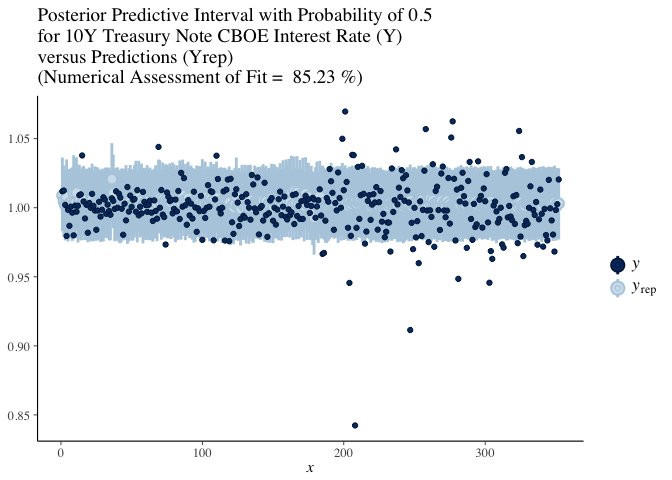

```r
##:::::::::::::::::::: Graphical Assessment of Calibration:
ppc_intervals(y = response_vars_sub$TNX_close_perc_open,
              yrep = post_mat_Y_tilde[ ,
                                       grep(",3]", ## because colnames(response_vars_sub)[3]
                                            colnames(post_mat_Y_tilde),
                                            fixed = TRUE)
                                       ],
              prob = 0.5
) +
  ggtitle(
    paste(
      "Posterior Predictive Interval with Probability of 0.5\nfor 10Y Treasury Note CBOE Interest Rate (Y)\nversus Predictions (Yrep)",
      "\n(Numerical Assessment of Fit = ",
      print(
        round( tnx_fit * 100, digits = 2)
      ),
      "%)"
    )
  )
```

Since the `tnx_fit` > 50%, the model is over fitting because 85.23% of the data are fitting in the 50% interval.

**`VIX_close_perc_open` - VIX Index:**

```r
##:::::::::::::::::::: Numerical Assessment of Calibration:
lower_vix <- apply(
  post_mat_Y_tilde[ ,
                                       grep(",4]", ## because colnames(response_vars_sub)[4]
                                            colnames(post_mat_Y_tilde),
                                            fixed = TRUE)
                                       ],
  MARGIN = 2,
  quantile,
  probs = 0.25
)


upper_vix <- apply(
  post_mat_Y_tilde[ ,
                                       grep(",4]", ## because colnames(response_vars_sub)[4]
                                            colnames(post_mat_Y_tilde),
                                            fixed = TRUE)
                                       ],
  MARGIN = 2,
  quantile,
  probs = 0.75
)


vix_fit <- mean(response_vars_sub$VIX_close_perc_open > lower_vix &
       response_vars_sub$VIX_close_perc_open < upper_vix)

vix_fit
```

```
## [1] 0.4261364
```

```
## [1] 42.61
```

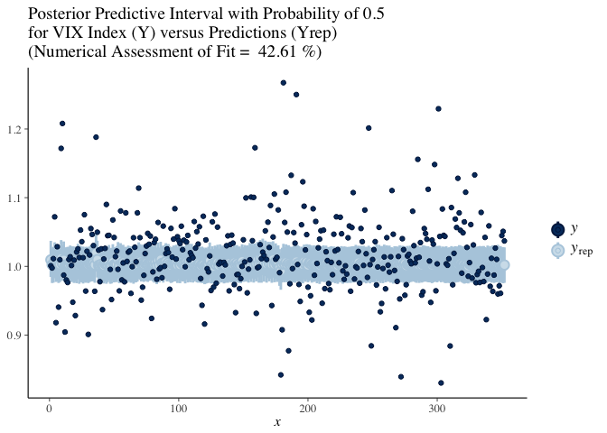

```r
##:::::::::::::::::::: Graphical Assessment of Calibration:
ppc_intervals(y = response_vars_sub$VIX_close_perc_open,
              yrep = post_mat_Y_tilde[ ,
                                       grep(",4]", ## because colnames(response_vars_sub)[4]
                                            colnames(post_mat_Y_tilde),
                                            fixed = TRUE)
                                       ],
              prob = 0.5
) +
  ggtitle(
    paste(
      "Posterior Predictive Interval with Probability of 0.5\nfor VIX Index (Y) versus Predictions (Yrep)",
      "\n(Numerical Assessment of Fit = ",
      print(
        round( vix_fit * 100, digits = 2)
      ),
      "%)"
    )
  )
```

Since the `vix_fit` < 50%, the model is under fitting because 42.61% of the data are fitting in the 50% interval.